# Explorar slides

```python
from wordcloud import WordCloud, STOPWORDS
import numpy as np
import matplotlib.pyplot as plt
import mysql.connector
import pandas as pd
from mlxtend.frequent_patterns import apriori, association_rules
```

#### Conexión directa al MySQL del OTRS

```python
cnx = mysql.connector.connect(user='usr_tronexotrs', password='usr$otrs#56aN7Rt*mp1',
                              host='pantermysql.cwqmr5tsjjh9.us-west-2.rds.amazonaws.com',
                              database='tronex.otrs')
```

#### Desde la consulta se filtran los siguientes tickets para limpiar los datos:

- activity@activityemail.com --> los tickets automáticos que se crean desde SFA (excluido temporalmente)
- soporte@sasaconsultoría.com --> los tickets auotmáticos de Sugar CRM
- telefonia@tronex.com --> tickets recibidos desde la planta telefónica
- serviciosit@tronex.com --> tickets automáticos de infraestructura
- se excluyen explícitamente los tickets que tiene la siguiente cadena en el título "has low free space"

```python
query = ('SELECT T.title, S.* FROM `tronex.otrs`.itv_sabana_tickets AS S INNER JOIN `tronex.otrs`.ticket AS T \
         ON S.ticket_id = T.id WHERE cola = "SERVICIOS IT" AND \
         correo_cliente NOT IN ("soporte@sasaconsultoria.com", "telefonia@tronex.com"\
         , "serviciosit@tronex.com") AND T.title not like "%has low free space" AND YEAR(S.fecha_creacion)=2020')

df = pd.read_sql(query, con=cnx)
```

#### Creación del wordcloud

Se incluye una lista de stopwords que fue generada mediante inspección visual del resultado

```python
comment_words = ''
stopwords = set(['con', 'el', 'de', 'la', 'y', 'para', 'por', 'a', 'no', 'del', 'sin', 'not', 'in', 're',
                 'se', 'rv', 'lo', 'las', 'en'])
for val in df.title:

    # typecaste each val to string
    val = str(val)

    # split the value
    tokens = val.split()
    tokens = [i.strip() for i in tokens]

    # Converts each token into lowercase
    for i in range(len(tokens)):
        tokens[i] = tokens[i].lower()

    comment_words += " ".join(tokens)+" "

wordcloud = WordCloud(width = 800, height = 800,
                background_color ='white',
                stopwords = stopwords,
                min_font_size = 10).generate(comment_words)
```

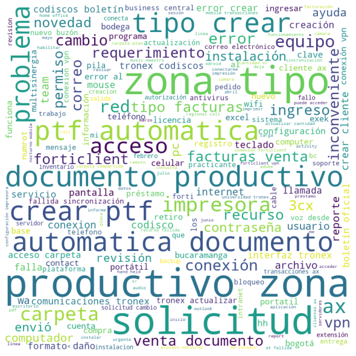

```python
plt.figure(figsize = (8, 8), facecolor = None)
plt.imshow(wordcloud)
plt.axis("off")
plt.tight_layout(pad = 0)

plt.show()
```

#### Función para graficar la distribución de los datos

```python
def show_distribution(var_data):

    # Get statistics
    min_val = var_data.min()
    max_val = var_data.max()
    mean_val = var_data.mean()
    med_val = var_data.median()
    mod_val = var_data.mode()[0]

    print('Minimum: {:,.2f}\nMean: {:,.2f}\nMedian: {:,.2f}\nMode: {:,.2f}\nMaximum: {:,.2f}\n'.format(min_val,
                                                                                            mean_val,
                                                                                            med_val,
                                                                                            mod_val,
                                                                                            max_val))

    # Create a figure for 2 subplots (2 rows, 1 column)
    fig, ax = plt.subplots(2, 1, figsize = (10,4))

    # Plot the histogram
    ax[0].hist(var_data, color='yellowgreen' , edgecolor="#6A9662")
    ax[0].set_ylabel('Frequency')

    # Add lines for the mean, median, and mode
    ax[0].axvline(x=min_val, color = 'gray', linestyle='dashed', linewidth = 2)
    ax[0].axvline(x=mean_val, color = 'cyan', linestyle='dashed', linewidth = 2)
    ax[0].axvline(x=med_val, color = 'red', linestyle='dashed', linewidth = 2)
    ax[0].axvline(x=mod_val, color = 'yellow', linestyle='dashed', linewidth = 2)
    ax[0].axvline(x=max_val, color = 'gray', linestyle='dashed', linewidth = 2)

    # Plot the boxplot
    ax[1].boxplot(var_data, vert=False)
    ax[1].set_xlabel('Value')

    # Add a title to the Figure
    fig.suptitle('Data Distribution')

    # Show the figure
#    fig.show()
```

```python
df1 = pd.Series(pd.to_timedelta(df.loc[df['asignado_cerrado'] != '0', 'asignado_cerrado'].values).seconds/3600)
```

```
Minimum: 0.00
Mean: 5.95
Median: 2.99
Mode: 23.00
Maximum: 24.00
```

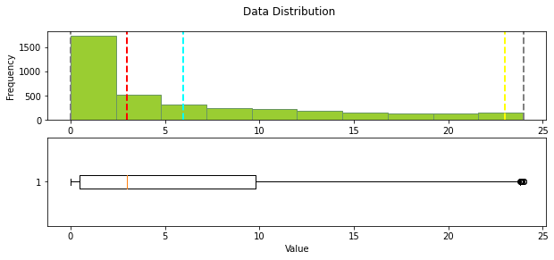

```python
show_distribution(df1[df1<10000])
```

Se excluyen por ser muy frecuentes los siguientes servicios:

- OFIMATICA::EQUIPOS DE COMPUTO
- OFIMATICA::APLICACIONES DE ESCRITORIO

```python
df['cantidad_servicio'] = 1

df_pivot = df.pivot_table(index='fecha_creacion', columns='servicio', aggfunc='sum', values='cantidad_servicio', fill_value=0)

df_pivot.drop(columns=['OFIMATICA::EQUIPOS DE COMPUTO', 'OFIMATICA::APLICACIONES DE ESCRITORIO'], inplace=True)

def encode(x):
    if x <= 0:
        return 0
    if x >= 1:
        return 1

df_pivot = df_pivot.applymap(encode)
```

#### Se calculan las reglas de asociación usando un soporte mínimo de datos del 30%

```python
df_freqserv = apriori(df_pivot, min_support=0.3, use_colnames=True)

df_rules = association_rules(df_freqserv, min_threshold=1, metric='lift')
```

#### Explicación de variables

- El antecedente implica el consecuente, no es conmutativo
- Support: Es la presencia en el dataset del antecedente, el consecuente y la regla en si
- Confidence: Es el porcentaje de los casos en el que la regla es cierta
- Lift: Cuando el valor es 1 son variables independientes, si es mayor son dependientes y si es menor son inversamente dependientes
- Conviction: es el error que habría en caso de que las variables sean independientes

```python
df_rules.loc[(df_rules.confidence>0.5)].sort_values('confidence', ascending=False).head(30)
```

|  | antecedents | consequents | antecedent support | consequent support | support | confidence | lift | leverage | conviction |
| --- | --- | --- | --- | --- | --- | --- | --- | --- | --- |
| 12 | (OFIMATICA::PERIFERICO) | (ERP::ADMINISTRACION) | 0.463087 | 0.640940 | 0.352349 | 0.760870 | 1.187116 | 0.055538 | 1.501525 |
| 18 | (MENSAJERIA Y COLABORACION::CORREO ELECTRONICO) | (MENSAJERIA Y COLABORACION::SERVIDOR DE ARCHIVOS) | 0.473154 | 0.620805 | 0.355705 | 0.751773 | 1.210964 | 0.061968 | 1.527613 |
| 23 | (TELEFONIA::TELEFONIA IP) | (MENSAJERIA Y COLABORACION::SERVIDOR DE ARCHIVOS) | 0.459732 | 0.620805 | 0.342282 | 0.744526 | 1.199290 | 0.056878 | 1.484276 |
| 14 | (TELEFONIA::TELEFONIA IP) | (ERP::ADMINISTRACION) | 0.459732 | 0.640940 | 0.338926 | 0.737226 | 1.150227 | 0.044266 | 1.366424 |
| 6 | (IMPRESION ::IMPRESION) | (ERP::ADMINISTRACION) | 0.483221 | 0.640940 | 0.352349 | 0.729167 | 1.137653 | 0.042633 | 1.325761 |
| 20 | (OFIMATICA::PERIFERICO) | (MENSAJERIA Y COLABORACION::SERVIDOR DE ARCHIVOS) | 0.463087 | 0.620805 | 0.332215 | 0.717391 | 1.155582 | 0.044728 | 1.341766 |
| 8 | (MENSAJERIA Y COLABORACION::CORREO ELECTRONICO) | (ERP::ADMINISTRACION) | 0.473154 | 0.640940 | 0.335570 | 0.709220 | 1.106532 | 0.032307 | 1.234817 |
| 10 | (MENSAJERIA Y COLABORACION::SERVIDOR DE ARCHIVOS) | (ERP::ADMINISTRACION) | 0.620805 | 0.640940 | 0.436242 | 0.702703 | 1.096363 | 0.038343 | 1.207749 |
| 0 | (AUTOMATIZACION FUERZA DE VENTAS::ADMINISTRACION) | (ERP::ADMINISTRACION) | 0.516779 | 0.640940 | 0.359060 | 0.694805 | 1.084042 | 0.027837 | 1.176496 |
| 16 | (IMPRESION ::IMPRESION) | (MENSAJERIA Y COLABORACION::SERVIDOR DE ARCHIVOS) | 0.483221 | 0.620805 | 0.335570 | 0.694444 | 1.118619 | 0.035584 | 1.241001 |
| 4 | (AUTOMATIZACION FUERZA DE VENTAS::ADMINISTRACION) | (MENSAJERIA Y COLABORACION::SERVIDOR DE ARCHIVOS) | 0.516779 | 0.620805 | 0.355705 | 0.688312 | 1.108740 | 0.034886 | 1.216583 |
| 11 | (ERP::ADMINISTRACION) | (MENSAJERIA Y COLABORACION::SERVIDOR DE ARCHIVOS) | 0.640940 | 0.620805 | 0.436242 | 0.680628 | 1.096363 | 0.038343 | 1.187314 |
| 2 | (IMPRESION ::IMPRESION) | (AUTOMATIZACION FUERZA DE VENTAS::ADMINISTRACION) | 0.483221 | 0.516779 | 0.308725 | 0.638889 | 1.236291 | 0.059006 | 1.338152 |
| 3 | (AUTOMATIZACION FUERZA DE VENTAS::ADMINISTRACION) | (IMPRESION ::IMPRESION) | 0.516779 | 0.483221 | 0.308725 | 0.597403 | 1.236291 | 0.059006 | 1.283611 |
| 19 | (MENSAJERIA Y COLABORACION::SERVIDOR DE ARCHIVOS) | (MENSAJERIA Y COLABORACION::CORREO ELECTRONICO) | 0.620805 | 0.473154 | 0.355705 | 0.572973 | 1.210964 | 0.061968 | 1.233752 |
| 5 | (MENSAJERIA Y COLABORACION::SERVIDOR DE ARCHIVOS) | (AUTOMATIZACION FUERZA DE VENTAS::ADMINISTRACION) | 0.620805 | 0.516779 | 0.355705 | 0.572973 | 1.108740 | 0.034886 | 1.131595 |
| 1 | (ERP::ADMINISTRACION) | (AUTOMATIZACION FUERZA DE VENTAS::ADMINISTRACION) | 0.640940 | 0.516779 | 0.359060 | 0.560209 | 1.084042 | 0.027837 | 1.098754 |
| 22 | (MENSAJERIA Y COLABORACION::SERVIDOR DE ARCHIVOS) | (TELEFONIA::TELEFONIA IP) | 0.620805 | 0.459732 | 0.342282 | 0.551351 | 1.199290 | 0.056878 | 1.204213 |
| 7 | (ERP::ADMINISTRACION) | (IMPRESION ::IMPRESION) | 0.640940 | 0.483221 | 0.352349 | 0.549738 | 1.137653 | 0.042633 | 1.147729 |
| 13 | (ERP::ADMINISTRACION) | (OFIMATICA::PERIFERICO) | 0.640940 | 0.463087 | 0.352349 | 0.549738 | 1.187116 | 0.055538 | 1.192446 |
| 17 | (MENSAJERIA Y COLABORACION::SERVIDOR DE ARCHIVOS) | (IMPRESION ::IMPRESION) | 0.620805 | 0.483221 | 0.335570 | 0.540541 | 1.118619 | 0.035584 | 1.124753 |
| 21 | (MENSAJERIA Y COLABORACION::SERVIDOR DE ARCHIVOS) | (OFIMATICA::PERIFERICO) | 0.620805 | 0.463087 | 0.332215 | 0.535135 | 1.155582 | 0.044728 | 1.154987 |
| 15 | (ERP::ADMINISTRACION) | (TELEFONIA::TELEFONIA IP) | 0.640940 | 0.459732 | 0.338926 | 0.528796 | 1.150227 | 0.044266 | 1.146570 |
| 9 | (ERP::ADMINISTRACION) | (MENSAJERIA Y COLABORACION::CORREO ELECTRONICO) | 0.640940 | 0.473154 | 0.335570 | 0.523560 | 1.106532 | 0.032307 | 1.105797 |

```python
df4['antecedents'] = df4['antecedents'].apply(lambda x: set(x))
df4['consequents'] = df4['consequents'].apply(lambda x: set(x))
```

```python
df4[df4['antecedents'] == {'TELEFONIA::TELEFONIA IP'}]
```

[output not shown]

```python
df['fecha_creacion'] = pd.to_datetime(df['fecha_creacion'])
```

```python
df_serv = df.set_index('fecha_creacion').groupby([pd.Grouper(freq='D'), 'servicio_hijo'])[['cantidad_servicio']].sum().reset_index('servicio_hijo')
```

```python
df_serv.loc[df_serv.index == '2020-03']
```

[output not shown]

```python
df_serv.loc[df_serv.servicio_hijo == 'EQUIPOS DE COMPUTO', 'cantidad_servicio']
```

[output not shown]

```python
df_equ = df_serv.loc[(df_serv.index == '2021-03-15') & (df_serv.servicio_hijo == 'EQUIPOS DE COMPUTO'), 'cantidad_servicio'].reset_index()
```

```python
plt.figure(figsize=(10, 8))
plt.bar(df_equ.fecha_creacion, df_equ.cantidad_servicio)
```

[output not shown]